# Course Project

Amos Turin

2022-08-30

### Load packages

```r
library(ggplot2)
library(dplyr)
library(caret)
library(randomForest)
library(xgboost)
library(lubridate)
library(corrplot)
```

### Load the datasets

```r
training <- read.csv("https://d396qusza40orc.cloudfront.net/predmachlearn/pml-training.csv",
                     na.strings = c("", "NA"))

testing <- read.csv("https://d396qusza40orc.cloudfront.net/predmachlearn/pml-testing.csv",
                    na.strings = c("", "NA"))
```

### Quick look at the dataset

```r
head(training)
```

```
##   X user_name raw_timestamp_part_1 raw_timestamp_part_2   cvtd_timestamp
## 1 1  carlitos           1323084231               788290 05/12/2011 11:23
## 2 2  carlitos           1323084231               808298 05/12/2011 11:23
## 3 3  carlitos           1323084231               820366 05/12/2011 11:23
## 4 4  carlitos           1323084232               120339 05/12/2011 11:23
## 5 5  carlitos           1323084232               196328 05/12/2011 11:23
## 6 6  carlitos           1323084232               304277 05/12/2011 11:23
##   new_window num_window roll_belt pitch_belt yaw_belt total_accel_belt
## 1         no         11      1.41       8.07    -94.4                3
## 2         no         11      1.41       8.07    -94.4                3
## 3         no         11      1.42       8.07    -94.4                3
## 4         no         12      1.48       8.05    -94.4                3
## 5         no         12      1.48       8.07    -94.4                3
## 6         no         12      1.45       8.06    -94.4                3
##   kurtosis_roll_belt kurtosis_picth_belt kurtosis_yaw_belt skewness_roll_belt
```

[output cut: 251 more lines]

```r
numerics <- which(sapply(training, is.numeric))
chrs <- which(sapply(training, is.character))

print(paste("data has", dim(training)[2], "Variables"))
```

```
## [1] "data has 160 Variables"
```

```r
print(paste("of which", dim(training[,numerics])[2], "are numeric"))
```

```
## [1] "of which 123 are numeric"
```

```r
print(paste("and", dim(training[,chrs])[2], "are character"))
```

```
## [1] "and 37 are character"
```

Let’s take a quick look at the outcome variable classe

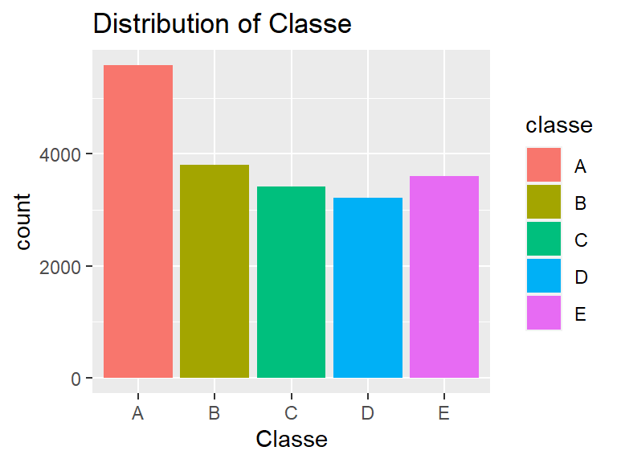

```r
ggplot(training, aes(x = as.factor(classe), fill = classe)) +
      geom_bar() +
      ggtitle("Distribution of Classe") +
      xlab("Classe")
```

Before preprocessing I’ll take a quick look at the missing values situation as I can already, at first glance, notice many missing values in the data.

```r
nas <- sapply(training, function(x) sum(is.na(x)))
nas[nas>0]
```

```
##       kurtosis_roll_belt      kurtosis_picth_belt        kurtosis_yaw_belt
##                    19216                    19216                    19216
##       skewness_roll_belt     skewness_roll_belt.1        skewness_yaw_belt
##                    19216                    19216                    19216
##            max_roll_belt           max_picth_belt             max_yaw_belt
##                    19216                    19216                    19216
##            min_roll_belt           min_pitch_belt             min_yaw_belt
##                    19216                    19216                    19216
##      amplitude_roll_belt     amplitude_pitch_belt       amplitude_yaw_belt
##                    19216                    19216                    19216
##     var_total_accel_belt            avg_roll_belt         stddev_roll_belt
##                    19216                    19216                    19216
##            var_roll_belt           avg_pitch_belt        stddev_pitch_belt
##                    19216                    19216                    19216
##           var_pitch_belt             avg_yaw_belt          stddev_yaw_belt
##                    19216                    19216                    19216
##             var_yaw_belt            var_accel_arm             avg_roll_arm
##                    19216                    19216                    19216
##          stddev_roll_arm             var_roll_arm            avg_pitch_arm
##                    19216                    19216                    19216
##         stddev_pitch_arm            var_pitch_arm              avg_yaw_arm
##                    19216                    19216                    19216
##           stddev_yaw_arm              var_yaw_arm        kurtosis_roll_arm
##                    19216                    19216                    19216
##       kurtosis_picth_arm         kurtosis_yaw_arm        skewness_roll_arm
##                    19216                    19216                    19216
##       skewness_pitch_arm         skewness_yaw_arm             max_roll_arm
##                    19216                    19216                    19216
##            max_picth_arm              max_yaw_arm             min_roll_arm
##                    19216                    19216                    19216
##            min_pitch_arm              min_yaw_arm       amplitude_roll_arm
##                    19216                    19216                    19216
##      amplitude_pitch_arm        amplitude_yaw_arm   kurtosis_roll_dumbbell
##                    19216                    19216                    19216
##  kurtosis_picth_dumbbell    kurtosis_yaw_dumbbell   skewness_roll_dumbbell
##                    19216                    19216                    19216
##  skewness_pitch_dumbbell    skewness_yaw_dumbbell        max_roll_dumbbell
##                    19216                    19216                    19216
##       max_picth_dumbbell         max_yaw_dumbbell        min_roll_dumbbell
##                    19216                    19216                    19216
```

[output cut: 13 more lines]

```
##                    19216                    19216                    19216
##         max_roll_forearm        max_picth_forearm          max_yaw_forearm
##                    19216                    19216                    19216
##         min_roll_forearm        min_pitch_forearm          min_yaw_forearm
##                    19216                    19216                    19216
##   amplitude_roll_forearm  amplitude_pitch_forearm    amplitude_yaw_forearm
##                    19216                    19216                    19216
##        var_accel_forearm         avg_roll_forearm      stddev_roll_forearm
##                    19216                    19216                    19216
##         var_roll_forearm        avg_pitch_forearm     stddev_pitch_forearm
##                    19216                    19216                    19216
##        var_pitch_forearm          avg_yaw_forearm       stddev_yaw_forearm
##                    19216                    19216                    19216
##          var_yaw_forearm
##                    19216
```

Ok, so 100 of the 160 variables have almost 98% missing values. With such a high proportion of missing values I don’t think imputation would provide any useful information for the classification stage so I will go ahead and remove these variables

```r
cols_to_drop <- names(nas[nas==19216])
training <- training %>% select(-c(cols_to_drop))
```

[output not shown]

```r
testing <- testing %>% select(-c(cols_to_drop))
```

Just a quick confirmation that the missing value situation is sorted

```r
nastrn <- sapply(training, function(x) sum(is.na(x)))
nastst <- sapply(testing, function(x) sum(is.na(x)))

print(paste("train NAs:", length(nastrn[nastrn>0]),
                                 "test NAs:", length(nastst[nastst>0])))
```

```
## [1] "train NAs: 0 test NAs: 0"
```

### PreProcessing the data

I’ll combine the train/test datasets for a quick preprocessing before splitting them again for the modelling phase

```r
testing$classe <- NA
# testing$problem_id is essentially a duplication of testing$X so I will drop it
testing <- testing %>% select(-problem_id)

df <- rbind(training, testing)

dim(df)
```

```
## [1] 19642    60
```

Converting datetime columns from numeric to datetime

```r
# raw_timestamp_part_1 and raw_timestamp_part_2
# I will create a new variable with the date and time of each observation
df$dateTimeStamp <- as.POSIXct(df$raw_timestamp_part_1, origin="1970-01-01")

# cvtd_timestamp is a character class and provides data up to the minute
df$cvtd_timestamp <- as.POSIXct(df$cvtd_timestamp, format = "%d/%m/%Y %H:%M")

# Not sure what raw_timeStamp_part_2 means so going to remove it for this analysis
# and as cvtd_timestamp does not contains less information than the new dateTimeStamp
# I will drop this as well
df <- df %>% select(-c(raw_timestamp_part_1, raw_timestamp_part_2, cvtd_timestamp))
```

Converting categorical variables to factors

```r
to_convert_fac <- c("user_name", "new_window", "classe")

to_convert_num <- c("total_accel_arm", "total_accel_belt", "total_accel_forearm",
                "total_accel_dumbbell", "num_window")

df <- df %>%
      mutate_at(to_convert_fac, as.factor) %>%
      mutate_at(to_convert_num, as.numeric) %>%
      select(-c(new_window))
```

### Split the datsets back into training and testing prior to further exploration

```r
training <- df %>%
      filter(is.na(classe)==FALSE) %>%
      select(-X)

testing <- df %>%
      filter(is.na(classe)==TRUE) %>%
      select(-X)
```

### Split the training set into train/test in order to have a validation set for the model

```r
set.seed(1234)
inTrain <- createDataPartition(y = training$classe, p = 0.75, list=FALSE)

train <- training[inTrain,]
test <- training[-inTrain,]
```

### Modelling

I’ll start by applying KNN classification. As KNN becomes exponentially more costly on large dimension data I will apply PCA to reduce the number of predictors and make the model more computationally efficient.

I’ll use cross-validation in order to train and test my model using varying subsets of the data to optimize my final model’s performance when making predictions on unseen data.

For each of the repetitions I will try to find the optimal K from a set of potential Ks outlined in the tuneGrid parameter.

After tuning the model for the first time, I achieve the best accuracy when k=3.

```r
# Start with a baseline classification model of KNN

set.seed(1234)

ctrl <- trainControl(method="repeatedcv",
                     repeats = 2,
                     number = 3,
                     preProcOptions = list(pcaComp = 7),
                     verboseIter = T)

knnFit <- train(classe ~ ., data = train,
                method = "knn",
                trControl = ctrl,
                preProcess = c("center","scale", "pca"),
                tuneGrid = expand.grid(k = c(3, 5, 7, 9, 11, 13, 15)))
#Output of kNN fit
knnFit
```

```
## k-Nearest Neighbors
##
## 14718 samples
##    55 predictor
##     5 classes: 'A', 'B', 'C', 'D', 'E'
##
## Pre-processing: centered (59), scaled (59), principal component
##  signal extraction (59)
## Resampling: Cross-Validated (3 fold, repeated 2 times)
## Summary of sample sizes: 9811, 9812, 9813, 9812, 9812, 9812, ...
## Resampling results across tuning parameters:
##
##   k   Accuracy   Kappa
##    3  0.8735555  0.8400838
##    5  0.8498771  0.8101672
##    7  0.8290522  0.7838829
##    9  0.8149199  0.7659909
##   11  0.8025202  0.7502442
##   13  0.7898147  0.7341589
##   15  0.7786038  0.7199892
##
## Accuracy was used to select the optimal model using the largest value.
## The final value used for the model was k = 3.
```

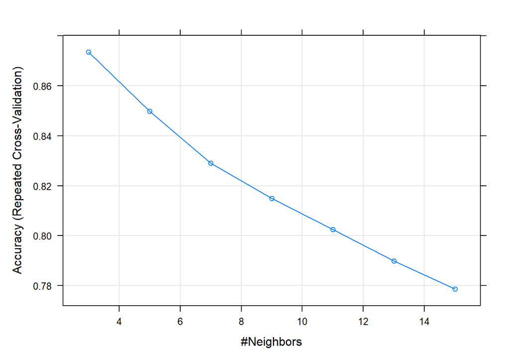

```r
plot(knnFit)
```

```r
knnPredict <- predict(knnFit,newdata = test)
```

Surprisingly, the accuracy on my test set is higher than on the train set. This may mean I am underfitting my model and need to increase its expressibility. I can try to do this by removing the PCA used to preProcess the model. Or alternatively, I may need to fit a different classification model.

```r
confusionMatrix(knnPredict, test$classe)
```

```
## Confusion Matrix and Statistics
##
##           Reference
## Prediction    A    B    C    D    E
##          A 1316   37   16   25   14
##          B   29  830   23   21   27
##          C   21   44  778   44   21
##          D   24   29   32  708   16
##          E    5    9    6    6  823
##
## Overall Statistics
##
##                Accuracy : 0.9084
##                  95% CI : (0.9, 0.9164)
##     No Information Rate : 0.2845
##     P-Value [Acc > NIR] : < 2.2e-16
##
##                   Kappa : 0.8842
##
##  Mcnemar's Test P-Value : 4.518e-05
##
## Statistics by Class:
##
##                      Class: A Class: B Class: C Class: D Class: E
## Sensitivity            0.9434   0.8746   0.9099   0.8806   0.9134
## Specificity            0.9738   0.9747   0.9679   0.9754   0.9935
## Pos Pred Value         0.9347   0.8925   0.8568   0.8752   0.9694
## Neg Pred Value         0.9774   0.9701   0.9807   0.9766   0.9808
## Prevalence             0.2845   0.1935   0.1743   0.1639   0.1837
## Detection Rate         0.2684   0.1692   0.1586   0.1444   0.1678
## Detection Prevalence   0.2871   0.1896   0.1852   0.1650   0.1731
## Balanced Accuracy      0.9586   0.9247   0.9389   0.9280   0.9535
```

### KNN take=2

This time I will try fitting the model without PCA to increase the model expressibility.

```r
set.seed(1234)

ctrl <- trainControl(method="repeatedcv",
                     repeats = 2,
                     number = 3,
                     verboseIter = T)

knnFit2 <- train(classe ~ ., data = train,
                method = "knn",
                trControl = ctrl,
                preProcess = c("center","scale"),
                tuneGrid = expand.grid(k = c(3, 5, 7, 9)))
#Output of kNN fit
knnFit2
```

```
## k-Nearest Neighbors
##
## 14718 samples
##    55 predictor
##     5 classes: 'A', 'B', 'C', 'D', 'E'
##
## Pre-processing: centered (59), scaled (59)
## Resampling: Cross-Validated (3 fold, repeated 2 times)
## Summary of sample sizes: 9811, 9812, 9813, 9812, 9812, 9812, ...
## Resampling results across tuning parameters:
##
##   k  Accuracy   Kappa
##   3  0.9676588  0.9590865
##   5  0.9512164  0.9382807
##   7  0.9365065  0.9196690
##   9  0.9233594  0.9030374
##
## Accuracy was used to select the optimal model using the largest value.
## The final value used for the model was k = 3.
```

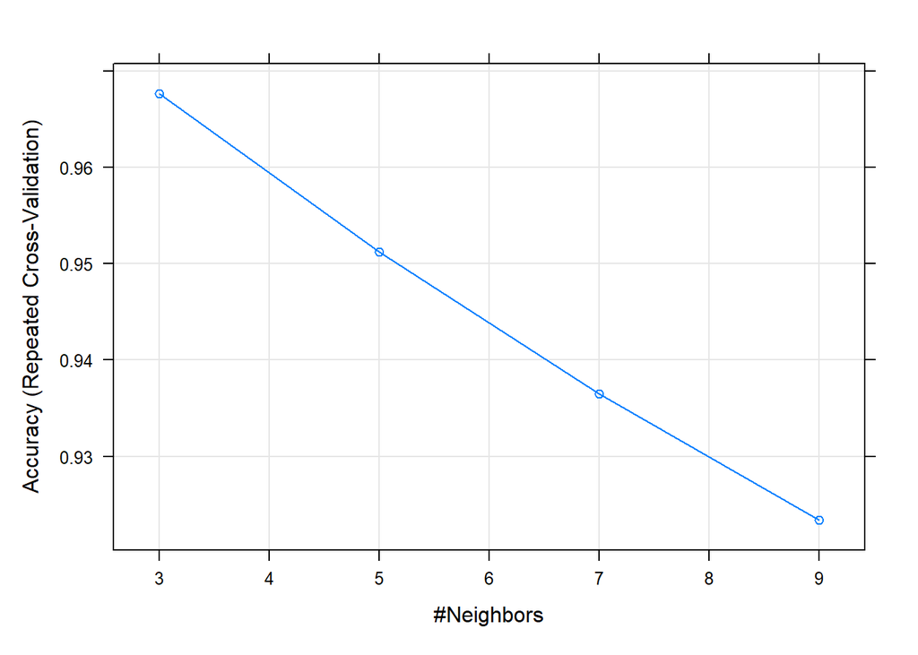

```r
plot(knnFit2)
```

```r
predictions <- predict(knnFit2, test)

confusionMatrix(predictions, test$classe)
```

```
## Confusion Matrix and Statistics
##
##           Reference
## Prediction    A    B    C    D    E
##          A 1385   16    0    3    0
##          B    6  921    9    0    2
##          C    3   11  832   21    4
##          D    1    1   13  777    0
##          E    0    0    1    3  895
##
## Overall Statistics
##
##                Accuracy : 0.9808
##                  95% CI : (0.9766, 0.9845)
##     No Information Rate : 0.2845
##     P-Value [Acc > NIR] : < 2.2e-16
##
##                   Kappa : 0.9757
##
##  Mcnemar's Test P-Value : NA
##
## Statistics by Class:
##
##                      Class: A Class: B Class: C Class: D Class: E
## Sensitivity            0.9928   0.9705   0.9731   0.9664   0.9933
## Specificity            0.9946   0.9957   0.9904   0.9963   0.9990
## Pos Pred Value         0.9865   0.9819   0.9552   0.9811   0.9956
## Neg Pred Value         0.9971   0.9929   0.9943   0.9934   0.9985
## Prevalence             0.2845   0.1935   0.1743   0.1639   0.1837
## Detection Rate         0.2824   0.1878   0.1697   0.1584   0.1825
## Detection Prevalence   0.2863   0.1913   0.1776   0.1615   0.1833
## Balanced Accuracy      0.9937   0.9831   0.9817   0.9814   0.9962
```

Before concluding I will try to use a different classification model to compare results. In this case I will use a Random Forest model.

```r
set.seed(1234)

ctrl <- trainControl(method="repeatedcv",
                     repeats = 2,
                     number = 4,
                     verboseIter = F,
                     search = "grid")

RanForFit <- train(classe ~ ., data = train,
                method = "rf",
                metric = "Accuracy",
                trControl = ctrl,
                tuneGrid = expand.grid(.mtry = (5:8)))

#Output of kNN fit
RanForFit
```

```
## Random Forest
##
## 14718 samples
##    55 predictor
##     5 classes: 'A', 'B', 'C', 'D', 'E'
##
## No pre-processing
## Resampling: Cross-Validated (4 fold, repeated 2 times)
## Summary of sample sizes: 11038, 11038, 11039, 11039, 11038, 11038, ...
## Resampling results across tuning parameters:
##
##   mtry  Accuracy   Kappa
##   5     0.9971124  0.9963475
##   6     0.9973842  0.9966912
##   7     0.9978937  0.9973358
##   8     0.9976899  0.9970780
##
## Accuracy was used to select the optimal model using the largest value.
## The final value used for the model was mtry = 7.
```

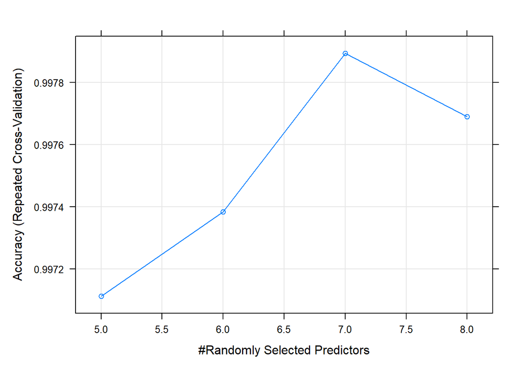

```r
plot(RanForFit)
```

```r
predictRF <- predict(RanForFit, test)

confusionMatrix(predictRF, test$classe)
```

```
## Confusion Matrix and Statistics
##
##           Reference
## Prediction    A    B    C    D    E
##          A 1395    0    0    0    0
##          B    0  949    4    0    0
##          C    0    0  851    0    0
##          D    0    0    0  804    0
##          E    0    0    0    0  901
##
## Overall Statistics
##
##                Accuracy : 0.9992
##                  95% CI : (0.9979, 0.9998)
##     No Information Rate : 0.2845
##     P-Value [Acc > NIR] : < 2.2e-16
##
##                   Kappa : 0.999
##
##  Mcnemar's Test P-Value : NA
##
## Statistics by Class:
##
##                      Class: A Class: B Class: C Class: D Class: E
## Sensitivity            1.0000   1.0000   0.9953   1.0000   1.0000
## Specificity            1.0000   0.9990   1.0000   1.0000   1.0000
## Pos Pred Value         1.0000   0.9958   1.0000   1.0000   1.0000
## Neg Pred Value         1.0000   1.0000   0.9990   1.0000   1.0000
## Prevalence             0.2845   0.1935   0.1743   0.1639   0.1837
## Detection Rate         0.2845   0.1935   0.1735   0.1639   0.1837
## Detection Prevalence   0.2845   0.1943   0.1735   0.1639   0.1837
## Balanced Accuracy      1.0000   0.9995   0.9977   1.0000   1.0000
```

Random forest results in almost perfect prediction. I will use this model to predict classes for the unseen testing dataset

```r
finalPred <- predict(RanForFit, testing)

finalPred
```

```
##  [1] B A B A A E D B A A B C B A E E A B B B
## Levels: A B C D E
```